# Risk Factor Analysis

## Outcome Variable

**Outcome Variable:** ever_stunted

## Predictor Variables

**Intervention Variable:** tr.x

**Adjustment Set:**

unadjusted

## Stratifying Variables

The analysis was stratified on these variable(s):

- fhtcm
- agecat
- studyid
- country

## Data Summary

| fhtcm | agecat | studyid | country | tr.x | ever_stunted | n_cell | n |
| --- | --- | --- | --- | --- | --- | --- | --- |
| <160 | 0-6 months | ki1000304b-SAS-CompFeed | INDIA | Control | 0 | 13 | 54 |
| <160 | 0-6 months | ki1000304b-SAS-CompFeed | INDIA | Control | 1 | 11 | 54 |
| <160 | 0-6 months | ki1000304b-SAS-CompFeed | INDIA | Other | 0 | 16 | 54 |
| <160 | 0-6 months | ki1000304b-SAS-CompFeed | INDIA | Other | 1 | 14 | 54 |
| >=170 | 0-6 months | ki1000304b-SAS-CompFeed | INDIA | Control | 0 | 43 | 110 |
| >=170 | 0-6 months | ki1000304b-SAS-CompFeed | INDIA | Control | 1 | 7 | 110 |
| >=170 | 0-6 months | ki1000304b-SAS-CompFeed | INDIA | Other | 0 | 48 | 110 |
| >=170 | 0-6 months | ki1000304b-SAS-CompFeed | INDIA | Other | 1 | 12 | 110 |
| [160-170) | 0-6 months | ki1000304b-SAS-CompFeed | INDIA | Control | 0 | 88 | 231 |
| [160-170) | 0-6 months | ki1000304b-SAS-CompFeed | INDIA | Control | 1 | 27 | 231 |
| [160-170) | 0-6 months | ki1000304b-SAS-CompFeed | INDIA | Other | 0 | 79 | 231 |
| [160-170) | 0-6 months | ki1000304b-SAS-CompFeed | INDIA | Other | 1 | 37 | 231 |
| <160 | 0-6 months | ki1000304b-SAS-FoodSuppl | INDIA | Control | 0 | 12 | 103 |
| <160 | 0-6 months | ki1000304b-SAS-FoodSuppl | INDIA | Control | 1 | 13 | 103 |
| <160 | 0-6 months | ki1000304b-SAS-FoodSuppl | INDIA | Other | 0 | 43 | 103 |
| <160 | 0-6 months | ki1000304b-SAS-FoodSuppl | INDIA | Other | 1 | 35 | 103 |
| [160-170) | 0-6 months | ki1000304b-SAS-FoodSuppl | INDIA | Control | 0 | 43 | 239 |
| [160-170) | 0-6 months | ki1000304b-SAS-FoodSuppl | INDIA | Control | 1 | 21 | 239 |
| [160-170) | 0-6 months | ki1000304b-SAS-FoodSuppl | INDIA | Other | 0 | 105 | 239 |
| [160-170) | 0-6 months | ki1000304b-SAS-FoodSuppl | INDIA | Other | 1 | 70 | 239 |
| >=170 | 0-6 months | ki1000304b-SAS-FoodSuppl | INDIA | Control | 0 | 6 | 55 |
| >=170 | 0-6 months | ki1000304b-SAS-FoodSuppl | INDIA | Control | 1 | 5 | 55 |
| >=170 | 0-6 months | ki1000304b-SAS-FoodSuppl | INDIA | Other | 0 | 36 | 55 |
| >=170 | 0-6 months | ki1000304b-SAS-FoodSuppl | INDIA | Other | 1 | 8 | 55 |
| >=170 | 0-6 months | ki1119695-PROBIT | BELARUS | Control | 0 | 5022 | 10735 |
| >=170 | 0-6 months | ki1119695-PROBIT | BELARUS | Control | 1 | 324 | 10735 |
| >=170 | 0-6 months | ki1119695-PROBIT | BELARUS | Other | 0 | 5083 | 10735 |
| >=170 | 0-6 months | ki1119695-PROBIT | BELARUS | Other | 1 | 306 | 10735 |
| [160-170) | 0-6 months | ki1119695-PROBIT | BELARUS | Control | 0 | 631 | 1335 |
| [160-170) | 0-6 months | ki1119695-PROBIT | BELARUS | Control | 1 | 68 | 1335 |

[output cut: 102 more lines]

The following strata were considered:

- fhtcm: [160-170), agecat: 0-24 months, studyid: ki1000304b-SAS-CompFeed, country: INDIA
- fhtcm: [160-170), agecat: 0-24 months, studyid: ki1000304b-SAS-FoodSuppl, country: INDIA
- fhtcm: [160-170), agecat: 0-24 months, studyid: ki1119695-PROBIT, country: BELARUS
- fhtcm: [160-170), agecat: 0-24 months, studyid: ki1135781-COHORTS, country: GUATEMALA
- fhtcm: [160-170), agecat: 0-6 months, studyid: ki1000304b-SAS-CompFeed, country: INDIA
- fhtcm: [160-170), agecat: 0-6 months, studyid: ki1000304b-SAS-FoodSuppl, country: INDIA
- fhtcm: [160-170), agecat: 0-6 months, studyid: ki1119695-PROBIT, country: BELARUS
- fhtcm: [160-170), agecat: 6-24 months, studyid: ki1000304b-SAS-CompFeed, country: INDIA
- fhtcm: [160-170), agecat: 6-24 months, studyid: ki1000304b-SAS-FoodSuppl, country: INDIA
- fhtcm: [160-170), agecat: 6-24 months, studyid: ki1119695-PROBIT, country: BELARUS
- fhtcm: [160-170), agecat: 6-24 months, studyid: ki1135781-COHORTS, country: GUATEMALA
- fhtcm: <160, agecat: 0-24 months, studyid: ki1000304b-SAS-CompFeed, country: INDIA
- fhtcm: <160, agecat: 0-24 months, studyid: ki1000304b-SAS-FoodSuppl, country: INDIA
- fhtcm: <160, agecat: 0-24 months, studyid: ki1119695-PROBIT, country: BELARUS
- fhtcm: <160, agecat: 0-24 months, studyid: ki1135781-COHORTS, country: GUATEMALA
- fhtcm: <160, agecat: 0-6 months, studyid: ki1000304b-SAS-CompFeed, country: INDIA
- fhtcm: <160, agecat: 0-6 months, studyid: ki1000304b-SAS-FoodSuppl, country: INDIA
- fhtcm: <160, agecat: 0-6 months, studyid: ki1119695-PROBIT, country: BELARUS
- fhtcm: <160, agecat: 6-24 months, studyid: ki1000304b-SAS-CompFeed, country: INDIA
- fhtcm: <160, agecat: 6-24 months, studyid: ki1000304b-SAS-FoodSuppl, country: INDIA
- fhtcm: <160, agecat: 6-24 months, studyid: ki1119695-PROBIT, country: BELARUS
- fhtcm: <160, agecat: 6-24 months, studyid: ki1135781-COHORTS, country: GUATEMALA
- fhtcm: >=170, agecat: 0-24 months, studyid: ki1000304b-SAS-CompFeed, country: INDIA
- fhtcm: >=170, agecat: 0-24 months, studyid: ki1000304b-SAS-FoodSuppl, country: INDIA
- fhtcm: >=170, agecat: 0-24 months, studyid: ki1119695-PROBIT, country: BELARUS
- fhtcm: >=170, agecat: 0-24 months, studyid: ki1135781-COHORTS, country: GUATEMALA
- fhtcm: >=170, agecat: 0-6 months, studyid: ki1000304b-SAS-CompFeed, country: INDIA
- fhtcm: >=170, agecat: 0-6 months, studyid: ki1000304b-SAS-FoodSuppl, country: INDIA
- fhtcm: >=170, agecat: 0-6 months, studyid: ki1119695-PROBIT, country: BELARUS
- fhtcm: >=170, agecat: 6-24 months, studyid: ki1000304b-SAS-CompFeed, country: INDIA
- fhtcm: >=170, agecat: 6-24 months, studyid: ki1000304b-SAS-FoodSuppl, country: INDIA
- fhtcm: >=170, agecat: 6-24 months, studyid: ki1119695-PROBIT, country: BELARUS
- fhtcm: >=170, agecat: 6-24 months, studyid: ki1135781-COHORTS, country: GUATEMALA

### Dropped Strata

Some strata were dropped due to rare outcomes:

- fhtcm: <160, agecat: 0-6 months, studyid: ki1119695-PROBIT, country: BELARUS
- fhtcm: >=170, agecat: 6-24 months, studyid: ki1000304b-SAS-FoodSuppl, country: INDIA
- fhtcm: <160, agecat: 6-24 months, studyid: ki1119695-PROBIT, country: BELARUS
- fhtcm: >=170, agecat: 6-24 months, studyid: ki1135781-COHORTS, country: GUATEMALA
- fhtcm: >=170, agecat: 0-24 months, studyid: ki1000304b-SAS-FoodSuppl, country: INDIA
- fhtcm: >=170, agecat: 0-24 months, studyid: ki1135781-COHORTS, country: GUATEMALA

## Methods Detail

We’re interested in the causal parameters $E[Y_a]$ for all values of $a \in \mathcal{A}$. These parameters represent the mean outcome if, possibly contrary to fact, we intervened to set all units to have $A=a$. Under the randomization and positivity assumptions, these are identified by the statistical parameters $\psi_a=E_W[E_{Y|A,W}(Y|A=a,W)]$. In addition, we’re interested in the mean of $Y$, $E[Y]$ under no intervention (the observed mean). We will estimate these parameters by using SuperLearner to fit the relevant likelihood factors – $E_{Y|A,W}(Y|A=a,W)$ and $p(A=a|W)$, and then updating our likelihood fit using a joint TMLE.

For unadjusted analyses ($W=\{\}$), initial likelihoods were estimated using Lrnr_glm to estimate the simple $E(Y|A)$ and Lrnr_mean to estimate $p(A)$. For adjusted analyses, a small library containing Lrnr_glmnet, Lrnr_xgboost, and Lrnr_mean was used.

Having estimated these parameters, we will then use the delta method to estimate relative risks and attributable risks relative to a prespecified baseline level of $A$.

# Results Detail

## Results Plots

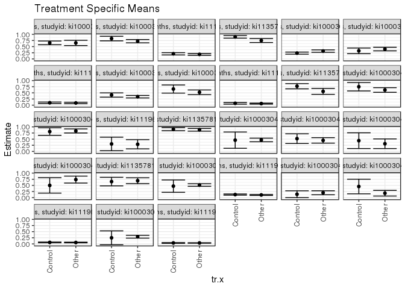

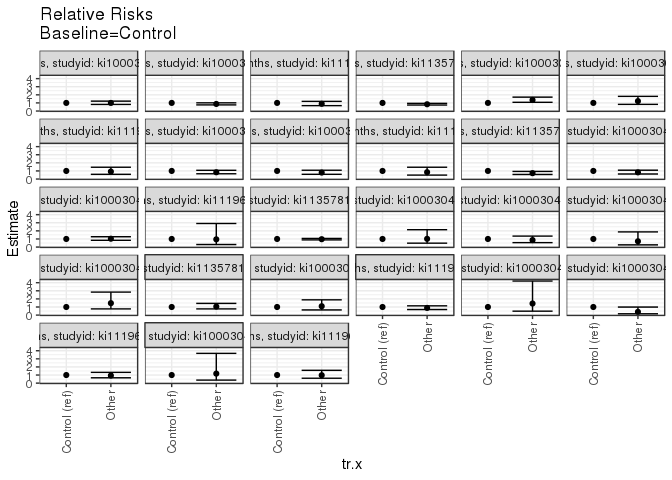

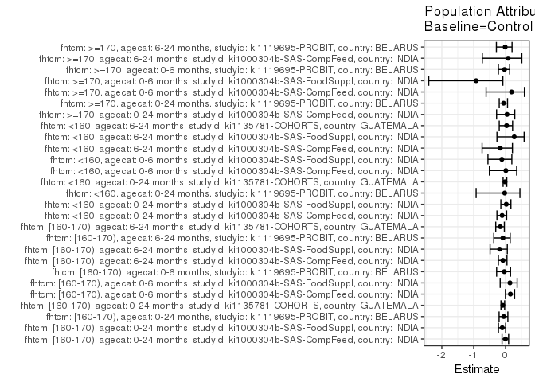

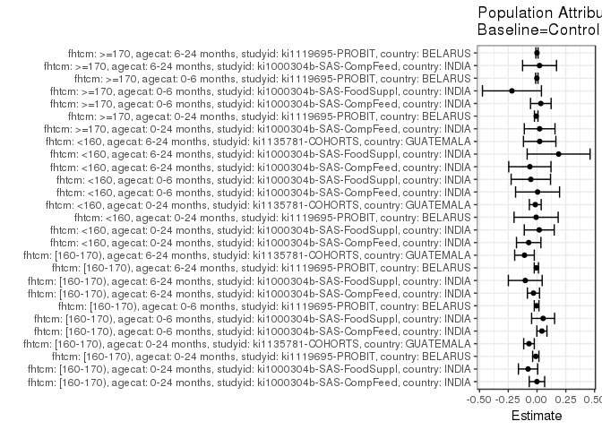

## Results Table

### Parameter: TSM

| fhtcm | agecat | studyid | country | intervention_level | baseline_level | estimate | ci_lower | ci_upper |
| --- | --- | --- | --- | --- | --- | --- | --- | --- |
| [160-170) | 0-24 months | ki1000304b-SAS-CompFeed | INDIA | Control | NA | 0.6521739 | 0.5754961 | 0.7288517 |
| [160-170) | 0-24 months | ki1000304b-SAS-CompFeed | INDIA | Other | NA | 0.6503497 | 0.5430833 | 0.7576160 |
| [160-170) | 0-24 months | ki1000304b-SAS-FoodSuppl | INDIA | Control | NA | 0.8281250 | 0.7355020 | 0.9207480 |
| [160-170) | 0-24 months | ki1000304b-SAS-FoodSuppl | INDIA | Other | NA | 0.7215909 | 0.6552341 | 0.7879477 |
| [160-170) | 0-24 months | ki1119695-PROBIT | BELARUS | Control | NA | 0.2071823 | 0.1612860 | 0.2530787 |
| [160-170) | 0-24 months | ki1119695-PROBIT | BELARUS | Other | NA | 0.1842900 | 0.1493080 | 0.2192721 |
| [160-170) | 0-24 months | ki1135781-COHORTS | GUATEMALA | Control | NA | 0.8976378 | 0.8448078 | 0.9504678 |
| [160-170) | 0-24 months | ki1135781-COHORTS | GUATEMALA | Other | NA | 0.7477477 | 0.6667830 | 0.8287125 |
| [160-170) | 0-6 months | ki1000304b-SAS-CompFeed | INDIA | Control | NA | 0.2347826 | 0.1926426 | 0.2769226 |
| [160-170) | 0-6 months | ki1000304b-SAS-CompFeed | INDIA | Other | NA | 0.3189655 | 0.2707138 | 0.3672172 |
| [160-170) | 0-6 months | ki1000304b-SAS-FoodSuppl | INDIA | Control | NA | 0.3281250 | 0.2128507 | 0.4433993 |
| [160-170) | 0-6 months | ki1000304b-SAS-FoodSuppl | INDIA | Other | NA | 0.4000000 | 0.3272647 | 0.4727353 |
| [160-170) | 0-6 months | ki1119695-PROBIT | BELARUS | Control | NA | 0.0972818 | 0.0665312 | 0.1280324 |
| [160-170) | 0-6 months | ki1119695-PROBIT | BELARUS | Other | NA | 0.0896226 | 0.0598173 | 0.1194280 |
| [160-170) | 6-24 months | ki1000304b-SAS-CompFeed | INDIA | Control | NA | 0.4123711 | 0.3257901 | 0.4989522 |
| [160-170) | 6-24 months | ki1000304b-SAS-CompFeed | INDIA | Other | NA | 0.3452381 | 0.2948799 | 0.3955963 |
| [160-170) | 6-24 months | ki1000304b-SAS-FoodSuppl | INDIA | Control | NA | 0.6562500 | 0.4910930 | 0.8214070 |
| [160-170) | 6-24 months | ki1000304b-SAS-FoodSuppl | INDIA | Other | NA | 0.5233645 | 0.4283873 | 0.6183417 |
| [160-170) | 6-24 months | ki1119695-PROBIT | BELARUS | Control | NA | 0.0753912 | 0.0419134 | 0.1088690 |
| [160-170) | 6-24 months | ki1119695-PROBIT | BELARUS | Other | NA | 0.0635659 | 0.0435412 | 0.0835906 |
| [160-170) | 6-24 months | ki1135781-COHORTS | GUATEMALA | Control | NA | 0.7704918 | 0.6645462 | 0.8764374 |
| [160-170) | 6-24 months | ki1135781-COHORTS | GUATEMALA | Other | NA | 0.5606061 | 0.4403938 | 0.6808183 |
| <160 | 0-24 months | ki1000304b-SAS-CompFeed | INDIA | Control | NA | 0.7500000 | 0.5780016 | 0.9219984 |
| <160 | 0-24 months | ki1000304b-SAS-CompFeed | INDIA | Other | NA | 0.6176471 | 0.5236671 | 0.7116270 |
| <160 | 0-24 months | ki1000304b-SAS-FoodSuppl | INDIA | Control | NA | 0.8076923 | 0.6554691 | 0.9599155 |
| <160 | 0-24 months | ki1000304b-SAS-FoodSuppl | INDIA | Other | NA | 0.8333333 | 0.7502273 | 0.9164394 |
| <160 | 0-24 months | ki1119695-PROBIT | BELARUS | Control | NA | 0.3043478 | 0.0284137 | 0.5802819 |
| <160 | 0-24 months | ki1119695-PROBIT | BELARUS | Other | NA | 0.2903226 | 0.1019427 | 0.4787024 |
| <160 | 0-24 months | ki1135781-COHORTS | GUATEMALA | Control | NA | 0.9047619 | 0.8418426 | 0.9676812 |
| <160 | 0-24 months | ki1135781-COHORTS | GUATEMALA | Other | NA | 0.8796992 | 0.8242843 | 0.9351141 |
| <160 | 0-6 months | ki1000304b-SAS-CompFeed | INDIA | Control | NA | 0.4583333 | 0.1265598 | 0.7901069 |
| <160 | 0-6 months | ki1000304b-SAS-CompFeed | INDIA | Other | NA | 0.4666667 | 0.3931680 | 0.5401653 |
| <160 | 0-6 months | ki1000304b-SAS-FoodSuppl | INDIA | Control | NA | 0.5200000 | 0.3232028 | 0.7167972 |
| <160 | 0-6 months | ki1000304b-SAS-FoodSuppl | INDIA | Other | NA | 0.4487179 | 0.3378023 | 0.5596336 |
| <160 | 6-24 months | ki1000304b-SAS-CompFeed | INDIA | Control | NA | 0.4375000 | 0.1165920 | 0.7584080 |
| <160 | 6-24 months | ki1000304b-SAS-CompFeed | INDIA | Other | NA | 0.3125000 | 0.1158969 | 0.5091031 |
| <160 | 6-24 months | ki1000304b-SAS-FoodSuppl | INDIA | Control | NA | 0.5000000 | 0.1868231 | 0.8131769 |
| <160 | 6-24 months | ki1000304b-SAS-FoodSuppl | INDIA | Other | NA | 0.7368421 | 0.5953529 | 0.8783313 |
| <160 | 6-24 months | ki1135781-COHORTS | GUATEMALA | Control | NA | 0.6551724 | 0.4811768 | 0.8291680 |
| <160 | 6-24 months | ki1135781-COHORTS | GUATEMALA | Other | NA | 0.6896552 | 0.5699032 | 0.8094072 |
| >=170 | 0-24 months | ki1000304b-SAS-CompFeed | INDIA | Control | NA | 0.4696970 | 0.2179655 | 0.7214284 |
| >=170 | 0-24 months | ki1000304b-SAS-CompFeed | INDIA | Other | NA | 0.5151515 | 0.4627006 | 0.5676024 |
| >=170 | 0-24 months | ki1119695-PROBIT | BELARUS | Control | NA | 0.1255907 | 0.1013663 | 0.1498151 |
| >=170 | 0-24 months | ki1119695-PROBIT | BELARUS | Other | NA | 0.1114291 | 0.0923401 | 0.1305181 |
| >=170 | 0-6 months | ki1000304b-SAS-CompFeed | INDIA | Control | NA | 0.1400000 | -0.0001585 | 0.2801585 |
| >=170 | 0-6 months | ki1000304b-SAS-CompFeed | INDIA | Other | NA | 0.2000000 | 0.1194846 | 0.2805154 |
| >=170 | 0-6 months | ki1000304b-SAS-FoodSuppl | INDIA | Control | NA | 0.4545455 | 0.1575812 | 0.7515097 |
| >=170 | 0-6 months | ki1000304b-SAS-FoodSuppl | INDIA | Other | NA | 0.1818182 | 0.0668044 | 0.2968319 |
| >=170 | 0-6 months | ki1119695-PROBIT | BELARUS | Control | NA | 0.0606061 | 0.0450946 | 0.0761175 |
| >=170 | 0-6 months | ki1119695-PROBIT | BELARUS | Other | NA | 0.0567823 | 0.0430210 | 0.0705436 |
| >=170 | 6-24 months | ki1000304b-SAS-CompFeed | INDIA | Control | NA | 0.2500000 | -0.0315705 | 0.5315705 |
| >=170 | 6-24 months | ki1000304b-SAS-CompFeed | INDIA | Other | NA | 0.2941176 | 0.2363377 | 0.3518976 |
| >=170 | 6-24 months | ki1119695-PROBIT | BELARUS | Control | NA | 0.0396679 | 0.0232480 | 0.0560878 |
| >=170 | 6-24 months | ki1119695-PROBIT | BELARUS | Other | NA | 0.0387050 | 0.0290220 | 0.0483880 |

### Parameter: E(Y)

| fhtcm | agecat | studyid | country | intervention_level | baseline_level | estimate | ci_lower | ci_upper |
| --- | --- | --- | --- | --- | --- | --- | --- | --- |
| [160-170) | 0-24 months | ki1000304b-SAS-CompFeed | INDIA | NA | NA | 0.6512456 | 0.5848473 | 0.7176438 |
| [160-170) | 0-24 months | ki1000304b-SAS-FoodSuppl | INDIA | NA | NA | 0.7500000 | 0.6951029 | 0.8048971 |
| [160-170) | 0-24 months | ki1119695-PROBIT | BELARUS | NA | NA | 0.1962482 | 0.1658508 | 0.2266456 |
| [160-170) | 0-24 months | ki1135781-COHORTS | GUATEMALA | NA | NA | 0.8277311 | 0.7796558 | 0.8758064 |
| [160-170) | 0-6 months | ki1000304b-SAS-CompFeed | INDIA | NA | NA | 0.2770563 | 0.2273407 | 0.3267718 |
| [160-170) | 0-6 months | ki1000304b-SAS-FoodSuppl | INDIA | NA | NA | 0.3807531 | 0.3190634 | 0.4424429 |
| [160-170) | 0-6 months | ki1119695-PROBIT | BELARUS | NA | NA | 0.0936330 | 0.0720741 | 0.1151918 |
| [160-170) | 6-24 months | ki1000304b-SAS-CompFeed | INDIA | NA | NA | 0.3812155 | 0.3267498 | 0.4356811 |
| [160-170) | 6-24 months | ki1000304b-SAS-FoodSuppl | INDIA | NA | NA | 0.5539568 | 0.4710224 | 0.6368913 |
| [160-170) | 6-24 months | ki1119695-PROBIT | BELARUS | NA | NA | 0.0697329 | 0.0495745 | 0.0898914 |
| [160-170) | 6-24 months | ki1135781-COHORTS | GUATEMALA | NA | NA | 0.6614173 | 0.5787882 | 0.7440464 |
| <160 | 0-24 months | ki1000304b-SAS-CompFeed | INDIA | NA | NA | 0.6774194 | 0.5717770 | 0.7830617 |
| <160 | 0-24 months | ki1000304b-SAS-FoodSuppl | INDIA | NA | NA | 0.8269231 | 0.7538627 | 0.8999834 |
| <160 | 0-24 months | ki1119695-PROBIT | BELARUS | NA | NA | 0.2962963 | 0.1366219 | 0.4559707 |
| <160 | 0-24 months | ki1135781-COHORTS | GUATEMALA | NA | NA | 0.8894009 | 0.8475750 | 0.9312269 |
| <160 | 0-6 months | ki1000304b-SAS-CompFeed | INDIA | NA | NA | 0.4629630 | 0.3119859 | 0.6139400 |
| <160 | 0-6 months | ki1000304b-SAS-FoodSuppl | INDIA | NA | NA | 0.4660194 | 0.3692111 | 0.5628278 |
| <160 | 6-24 months | ki1000304b-SAS-CompFeed | INDIA | NA | NA | 0.3750000 | 0.1708371 | 0.5791629 |
| <160 | 6-24 months | ki1000304b-SAS-FoodSuppl | INDIA | NA | NA | 0.6875000 | 0.5549864 | 0.8200136 |
| <160 | 6-24 months | ki1135781-COHORTS | GUATEMALA | NA | NA | 0.6781609 | 0.5794228 | 0.7768990 |
| >=170 | 0-24 months | ki1000304b-SAS-CompFeed | INDIA | NA | NA | 0.4924242 | 0.3673124 | 0.6175361 |
| >=170 | 0-24 months | ki1119695-PROBIT | BELARUS | NA | NA | 0.1184531 | 0.1021887 | 0.1347175 |
| >=170 | 0-6 months | ki1000304b-SAS-CompFeed | INDIA | NA | NA | 0.1727273 | 0.0933417 | 0.2521128 |
| >=170 | 0-6 months | ki1000304b-SAS-FoodSuppl | INDIA | NA | NA | 0.2363636 | 0.1230493 | 0.3496780 |
| >=170 | 0-6 months | ki1119695-PROBIT | BELARUS | NA | NA | 0.0586865 | 0.0481718 | 0.0692013 |
| >=170 | 6-24 months | ki1000304b-SAS-CompFeed | INDIA | NA | NA | 0.2718447 | 0.1307722 | 0.4129171 |
| >=170 | 6-24 months | ki1119695-PROBIT | BELARUS | NA | NA | 0.0391817 | 0.0296414 | 0.0487219 |

### Parameter: RR

| fhtcm | agecat | studyid | country | intervention_level | baseline_level | estimate | ci_lower | ci_upper |
| --- | --- | --- | --- | --- | --- | --- | --- | --- |
| [160-170) | 0-24 months | ki1000304b-SAS-CompFeed | INDIA | Control | Control | 1.0000000 | 1.0000000 | 1.0000000 |
| [160-170) | 0-24 months | ki1000304b-SAS-CompFeed | INDIA | Other | Control | 0.9972028 | 0.8147211 | 1.2205568 |
| [160-170) | 0-24 months | ki1000304b-SAS-FoodSuppl | INDIA | Control | Control | 1.0000000 | 1.0000000 | 1.0000000 |
| [160-170) | 0-24 months | ki1000304b-SAS-FoodSuppl | INDIA | Other | Control | 0.8713551 | 0.7538946 | 1.0071164 |
| [160-170) | 0-24 months | ki1119695-PROBIT | BELARUS | Control | Control | 1.0000000 | 1.0000000 | 1.0000000 |
| [160-170) | 0-24 months | ki1119695-PROBIT | BELARUS | Other | Control | 0.8895065 | 0.6655714 | 1.1887859 |
| [160-170) | 0-24 months | ki1135781-COHORTS | GUATEMALA | Control | Control | 1.0000000 | 1.0000000 | 1.0000000 |
| [160-170) | 0-24 months | ki1135781-COHORTS | GUATEMALA | Other | Control | 0.8330172 | 0.7364303 | 0.9422720 |
| [160-170) | 0-6 months | ki1000304b-SAS-CompFeed | INDIA | Control | Control | 1.0000000 | 1.0000000 | 1.0000000 |
| [160-170) | 0-6 months | ki1000304b-SAS-CompFeed | INDIA | Other | Control | 1.3585568 | 1.0774292 | 1.7130376 |
| [160-170) | 0-6 months | ki1000304b-SAS-FoodSuppl | INDIA | Control | Control | 1.0000000 | 1.0000000 | 1.0000000 |
| [160-170) | 0-6 months | ki1000304b-SAS-FoodSuppl | INDIA | Other | Control | 1.2190476 | 0.8207700 | 1.8105890 |
| [160-170) | 0-6 months | ki1119695-PROBIT | BELARUS | Control | Control | 1.0000000 | 1.0000000 | 1.0000000 |
| [160-170) | 0-6 months | ki1119695-PROBIT | BELARUS | Other | Control | 0.9212680 | 0.5815070 | 1.4595435 |
| [160-170) | 6-24 months | ki1000304b-SAS-CompFeed | INDIA | Control | Control | 1.0000000 | 1.0000000 | 1.0000000 |
| [160-170) | 6-24 months | ki1000304b-SAS-CompFeed | INDIA | Other | Control | 0.8372024 | 0.6493719 | 1.0793628 |
| [160-170) | 6-24 months | ki1000304b-SAS-FoodSuppl | INDIA | Control | Control | 1.0000000 | 1.0000000 | 1.0000000 |
| [160-170) | 6-24 months | ki1000304b-SAS-FoodSuppl | INDIA | Other | Control | 0.7975078 | 0.5847697 | 1.0876395 |
| [160-170) | 6-24 months | ki1119695-PROBIT | BELARUS | Control | Control | 1.0000000 | 1.0000000 | 1.0000000 |
| [160-170) | 6-24 months | ki1119695-PROBIT | BELARUS | Other | Control | 0.8431476 | 0.4884082 | 1.4555403 |
| [160-170) | 6-24 months | ki1135781-COHORTS | GUATEMALA | Control | Control | 1.0000000 | 1.0000000 | 1.0000000 |
| [160-170) | 6-24 months | ki1135781-COHORTS | GUATEMALA | Other | Control | 0.7275951 | 0.5639763 | 0.9386824 |
| <160 | 0-24 months | ki1000304b-SAS-CompFeed | INDIA | Control | Control | 1.0000000 | 1.0000000 | 1.0000000 |
| <160 | 0-24 months | ki1000304b-SAS-CompFeed | INDIA | Other | Control | 0.8235294 | 0.6214305 | 1.0913541 |
| <160 | 0-24 months | ki1000304b-SAS-FoodSuppl | INDIA | Control | Control | 1.0000000 | 1.0000000 | 1.0000000 |
| <160 | 0-24 months | ki1000304b-SAS-FoodSuppl | INDIA | Other | Control | 1.0317460 | 0.8336236 | 1.2769550 |
| <160 | 0-24 months | ki1119695-PROBIT | BELARUS | Control | Control | 1.0000000 | 1.0000000 | 1.0000000 |
| <160 | 0-24 months | ki1119695-PROBIT | BELARUS | Other | Control | 0.9539171 | 0.3128216 | 2.9088711 |
| <160 | 0-24 months | ki1135781-COHORTS | GUATEMALA | Control | Control | 1.0000000 | 1.0000000 | 1.0000000 |
| <160 | 0-24 months | ki1135781-COHORTS | GUATEMALA | Other | Control | 0.9722992 | 0.8852167 | 1.0679483 |
| <160 | 0-6 months | ki1000304b-SAS-CompFeed | INDIA | Control | Control | 1.0000000 | 1.0000000 | 1.0000000 |
| <160 | 0-6 months | ki1000304b-SAS-CompFeed | INDIA | Other | Control | 1.0181818 | 0.4827491 | 2.1474804 |
| <160 | 0-6 months | ki1000304b-SAS-FoodSuppl | INDIA | Control | Control | 1.0000000 | 1.0000000 | 1.0000000 |
| <160 | 0-6 months | ki1000304b-SAS-FoodSuppl | INDIA | Other | Control | 0.8629191 | 0.5491072 | 1.3560731 |
| <160 | 6-24 months | ki1000304b-SAS-CompFeed | INDIA | Control | Control | 1.0000000 | 1.0000000 | 1.0000000 |
| <160 | 6-24 months | ki1000304b-SAS-CompFeed | INDIA | Other | Control | 0.7142857 | 0.2722939 | 1.8737259 |
| <160 | 6-24 months | ki1000304b-SAS-FoodSuppl | INDIA | Control | Control | 1.0000000 | 1.0000000 | 1.0000000 |
| <160 | 6-24 months | ki1000304b-SAS-FoodSuppl | INDIA | Other | Control | 1.4736842 | 0.7653964 | 2.8374123 |
| <160 | 6-24 months | ki1135781-COHORTS | GUATEMALA | Control | Control | 1.0000000 | 1.0000000 | 1.0000000 |
| <160 | 6-24 months | ki1135781-COHORTS | GUATEMALA | Other | Control | 1.0526316 | 0.7664336 | 1.4457002 |
| >=170 | 0-24 months | ki1000304b-SAS-CompFeed | INDIA | Control | Control | 1.0000000 | 1.0000000 | 1.0000000 |
| >=170 | 0-24 months | ki1000304b-SAS-CompFeed | INDIA | Other | Control | 1.0967742 | 0.6378137 | 1.8859952 |
| >=170 | 0-24 months | ki1119695-PROBIT | BELARUS | Control | Control | 1.0000000 | 1.0000000 | 1.0000000 |
| >=170 | 0-24 months | ki1119695-PROBIT | BELARUS | Other | Control | 0.8872400 | 0.6873968 | 1.1451825 |
| >=170 | 0-6 months | ki1000304b-SAS-CompFeed | INDIA | Control | Control | 1.0000000 | 1.0000000 | 1.0000000 |
| >=170 | 0-6 months | ki1000304b-SAS-CompFeed | INDIA | Other | Control | 1.4285714 | 0.4852726 | 4.2055048 |
| >=170 | 0-6 months | ki1000304b-SAS-FoodSuppl | INDIA | Control | Control | 1.0000000 | 1.0000000 | 1.0000000 |
| >=170 | 0-6 months | ki1000304b-SAS-FoodSuppl | INDIA | Other | Control | 0.4000000 | 0.1611088 | 0.9931179 |
| >=170 | 0-6 months | ki1119695-PROBIT | BELARUS | Control | Control | 1.0000000 | 1.0000000 | 1.0000000 |
| >=170 | 0-6 months | ki1119695-PROBIT | BELARUS | Other | Control | 0.9369085 | 0.6595172 | 1.3309699 |
| >=170 | 6-24 months | ki1000304b-SAS-CompFeed | INDIA | Control | Control | 1.0000000 | 1.0000000 | 1.0000000 |
| >=170 | 6-24 months | ki1000304b-SAS-CompFeed | INDIA | Other | Control | 1.1764706 | 0.3768915 | 3.6723646 |
| >=170 | 6-24 months | ki1119695-PROBIT | BELARUS | Control | Control | 1.0000000 | 1.0000000 | 1.0000000 |
| >=170 | 6-24 months | ki1119695-PROBIT | BELARUS | Other | Control | 0.9757263 | 0.6025686 | 1.5799726 |

### Parameter: PAR

| fhtcm | agecat | studyid | country | intervention_level | baseline_level | estimate | ci_lower | ci_upper |
| --- | --- | --- | --- | --- | --- | --- | --- | --- |
| [160-170) | 0-24 months | ki1000304b-SAS-CompFeed | INDIA | Control | NA | -0.0009284 | -0.0679017 | 0.0660450 |
| [160-170) | 0-24 months | ki1000304b-SAS-FoodSuppl | INDIA | Control | NA | -0.0781250 | -0.1618940 | 0.0056440 |
| [160-170) | 0-24 months | ki1119695-PROBIT | BELARUS | Control | NA | -0.0109341 | -0.0382343 | 0.0163661 |
| [160-170) | 0-24 months | ki1135781-COHORTS | GUATEMALA | Control | NA | -0.0699067 | -0.1159893 | -0.0238241 |
| [160-170) | 0-6 months | ki1000304b-SAS-CompFeed | INDIA | Control | NA | 0.0422737 | -0.0015396 | 0.0860869 |
| [160-170) | 0-6 months | ki1000304b-SAS-FoodSuppl | INDIA | Control | NA | 0.0526281 | -0.0472574 | 0.1525137 |
| [160-170) | 0-6 months | ki1119695-PROBIT | BELARUS | Control | NA | -0.0036489 | -0.0239774 | 0.0166796 |
| [160-170) | 6-24 months | ki1000304b-SAS-CompFeed | INDIA | Control | NA | -0.0311557 | -0.0837725 | 0.0214612 |
| [160-170) | 6-24 months | ki1000304b-SAS-FoodSuppl | INDIA | Control | NA | -0.1022932 | -0.2492484 | 0.0446621 |
| [160-170) | 6-24 months | ki1119695-PROBIT | BELARUS | Control | NA | -0.0056582 | -0.0242138 | 0.0128973 |
| [160-170) | 6-24 months | ki1135781-COHORTS | GUATEMALA | Control | NA | -0.1090745 | -0.1943357 | -0.0238133 |
| <160 | 0-24 months | ki1000304b-SAS-CompFeed | INDIA | Control | NA | -0.0725806 | -0.1786971 | 0.0335358 |
| <160 | 0-24 months | ki1000304b-SAS-FoodSuppl | INDIA | Control | NA | 0.0192308 | -0.1108606 | 0.1493221 |
| <160 | 0-24 months | ki1119695-PROBIT | BELARUS | Control | NA | -0.0080515 | -0.1998238 | 0.1837208 |
| <160 | 0-24 months | ki1135781-COHORTS | GUATEMALA | Control | NA | -0.0153610 | -0.0667744 | 0.0360525 |
| <160 | 0-6 months | ki1000304b-SAS-CompFeed | INDIA | Control | NA | 0.0046296 | -0.1864513 | 0.1957106 |
| <160 | 0-6 months | ki1000304b-SAS-FoodSuppl | INDIA | Control | NA | -0.0539806 | -0.2251543 | 0.1171931 |
| <160 | 6-24 months | ki1000304b-SAS-CompFeed | INDIA | Control | NA | -0.0625000 | -0.2460975 | 0.1210975 |
| <160 | 6-24 months | ki1000304b-SAS-FoodSuppl | INDIA | Control | NA | 0.1875000 | -0.0859467 | 0.4609467 |
| <160 | 6-24 months | ki1135781-COHORTS | GUATEMALA | Control | NA | 0.0229885 | -0.1178685 | 0.1638455 |
| >=170 | 0-24 months | ki1000304b-SAS-CompFeed | INDIA | Control | NA | 0.0227273 | -0.1105922 | 0.1560468 |
| >=170 | 0-24 months | ki1119695-PROBIT | BELARUS | Control | NA | -0.0071376 | -0.0226315 | 0.0083563 |
| >=170 | 0-6 months | ki1000304b-SAS-CompFeed | INDIA | Control | NA | 0.0327273 | -0.0567605 | 0.1222151 |
| >=170 | 0-6 months | ki1000304b-SAS-FoodSuppl | INDIA | Control | NA | -0.2181818 | -0.4746049 | 0.0382413 |
| >=170 | 0-6 months | ki1119695-PROBIT | BELARUS | Control | NA | -0.0019195 | -0.0122854 | 0.0084464 |
| >=170 | 6-24 months | ki1000304b-SAS-CompFeed | INDIA | Control | NA | 0.0218447 | -0.1256111 | 0.1693004 |
| >=170 | 6-24 months | ki1119695-PROBIT | BELARUS | Control | NA | -0.0004862 | -0.0100827 | 0.0091102 |

### Parameter: PAF

| fhtcm | agecat | studyid | country | intervention_level | baseline_level | estimate | ci_lower | ci_upper |
| --- | --- | --- | --- | --- | --- | --- | --- | --- |
| [160-170) | 0-24 months | ki1000304b-SAS-CompFeed | INDIA | Control | NA | -0.0014255 | -0.1097850 | 0.0963537 |
| [160-170) | 0-24 months | ki1000304b-SAS-FoodSuppl | INDIA | Control | NA | -0.1041667 | -0.2233134 | 0.0033756 |
| [160-170) | 0-24 months | ki1119695-PROBIT | BELARUS | Control | NA | -0.0557158 | -0.2021054 | 0.0728469 |
| [160-170) | 0-24 months | ki1135781-COHORTS | GUATEMALA | Control | NA | -0.0844558 | -0.1436903 | -0.0282892 |
| [160-170) | 0-6 months | ki1000304b-SAS-CompFeed | INDIA | Control | NA | 0.1525815 | -0.0036448 | 0.2844898 |
| [160-170) | 0-6 months | ki1000304b-SAS-FoodSuppl | INDIA | Control | NA | 0.1382212 | -0.1685022 | 0.3644318 |
| [160-170) | 0-6 months | ki1119695-PROBIT | BELARUS | Control | NA | -0.0389700 | -0.2798041 | 0.1565439 |
| [160-170) | 6-24 months | ki1000304b-SAS-CompFeed | INDIA | Control | NA | -0.0817272 | -0.2253931 | 0.0450953 |
| [160-170) | 6-24 months | ki1000304b-SAS-FoodSuppl | INDIA | Control | NA | -0.1846591 | -0.4854780 | 0.0552420 |
| [160-170) | 6-24 months | ki1119695-PROBIT | BELARUS | Control | NA | -0.0811416 | -0.3691116 | 0.1462587 |
| [160-170) | 6-24 months | ki1135781-COHORTS | GUATEMALA | Control | NA | -0.1649102 | -0.3076244 | -0.0377719 |
| <160 | 0-24 months | ki1000304b-SAS-CompFeed | INDIA | Control | NA | -0.1071429 | -0.2702278 | 0.0350036 |
| <160 | 0-24 months | ki1000304b-SAS-FoodSuppl | INDIA | Control | NA | 0.0232558 | -0.1475732 | 0.1686550 |
| <160 | 0-24 months | ki1119695-PROBIT | BELARUS | Control | NA | -0.0271739 | -0.9229218 | 0.4513109 |
| <160 | 0-24 months | ki1135781-COHORTS | GUATEMALA | Control | NA | -0.0172712 | -0.0768447 | 0.0390066 |
| <160 | 0-6 months | ki1000304b-SAS-CompFeed | INDIA | Control | NA | 0.0100000 | -0.5064485 | 0.3493969 |
| <160 | 0-6 months | ki1000304b-SAS-FoodSuppl | INDIA | Control | NA | -0.1158333 | -0.5518541 | 0.1976797 |
| <160 | 6-24 months | ki1000304b-SAS-CompFeed | INDIA | Control | NA | -0.1666667 | -0.7363894 | 0.2161257 |
| <160 | 6-24 months | ki1000304b-SAS-FoodSuppl | INDIA | Control | NA | 0.2727273 | -0.2697864 | 0.5834531 |
| <160 | 6-24 months | ki1135781-COHORTS | GUATEMALA | Control | NA | 0.0338983 | -0.1980467 | 0.2209381 |
| >=170 | 0-24 months | ki1000304b-SAS-CompFeed | INDIA | Control | NA | 0.0461538 | -0.2810405 | 0.2897785 |
| >=170 | 0-24 months | ki1119695-PROBIT | BELARUS | Control | NA | -0.0602569 | -0.1982340 | 0.0618321 |
| >=170 | 0-6 months | ki1000304b-SAS-CompFeed | INDIA | Control | NA | 0.1894737 | -0.6107847 | 0.5921535 |
| >=170 | 0-6 months | ki1000304b-SAS-FoodSuppl | INDIA | Control | NA | -0.9230769 | -2.4107328 | -0.0842904 |
| >=170 | 0-6 months | ki1119695-PROBIT | BELARUS | Control | NA | -0.0327080 | -0.2247387 | 0.1292135 |
| >=170 | 6-24 months | ki1000304b-SAS-CompFeed | INDIA | Control | NA | 0.0803571 | -0.7287014 | 0.5107640 |
| >=170 | 6-24 months | ki1119695-PROBIT | BELARUS | Control | NA | -0.0124098 | -0.2876987 | 0.2040269 |